## Assignment 10

#### Due Friday, April 21, 11:59 PM CT

### Preliminaries

- Directories
  - COURSE/homework/
  - COURSE/homework/hw10/
  - COURSE/data/
  - COURSE/scripts/
- Files
  - COURSE/homework/hw10/hw10.Rmd
  - COURSE/data/boston-marathon-data.csv
  - COURSE/data/madison-weather-official-1869-2022.csv
  - COURSE/scripts/viridis.R
  - COURSE/scripts/ggprob.R

### Data

- Some problems use the official Madison weather data, `madison-weather-official-1869-2022.csv`.
- Additional problems use the Boston Marathon data in the file `boston-marathon-data.csv`. This file is a transformed version of the raw data we used in class and has data for all runners who completed the race in 2010 and 2011. The variable `Time` is the sum of the times from the different portions of the race, each of which begins with “K”.

### Aims

- Practice inference on means

## Problems

**1.** Read in the official Madison weather data. Treat the high temperatures on the dates from April 14 from the past twenty years (2003–2022) as a random sample from a population of potential maximum temperatures in Madison under recent climate conditions at this time of the year. Let $\mu$ and $\sigma$ represent the unknown mean and standard deviations of this population of high temperatures.

- Calculate and display the summary statistics $n$, $\bar{x}$, and $s$, the sample standard deviation.
- Create a graph to display the distribution of this data. Choose which type of graph is effective for this purpose.
- Describe the distribution of daily maximum temperatures as shown by the graph. Is the distribution strongly skewed? Are there unusual measurements?

#### Solution

```r
official = read_csv("../../data/madison-weather-official-1869-2022.csv")

april_14 = official %>%
  filter(year(date) > 2002 &
           month(date) == 4 &
           day(date) == 14) %>%
  select(date, tmax)

april_14_sum = april_14 %>%
  summarize(n = n(), mean = mean(tmax), sd = sd(tmax))

april_14_sum
```

```
## # A tibble: 1 × 3
##       n  mean    sd
##   <int> <dbl> <dbl>
## 1    20  57.9  16.1
```

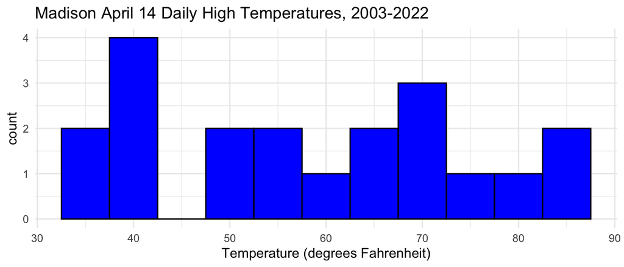

```r
ggplot(april_14, aes(x = tmax)) +
  geom_histogram(center = 60, binwidth = 5,
                 color = "black", fill = "blue") +
  xlab("Temperature (degrees Fahrenheit)") +
  ggtitle("Madison April 14 Daily High Temperatures, 2003-2022")
```

Here is an alternative graph.

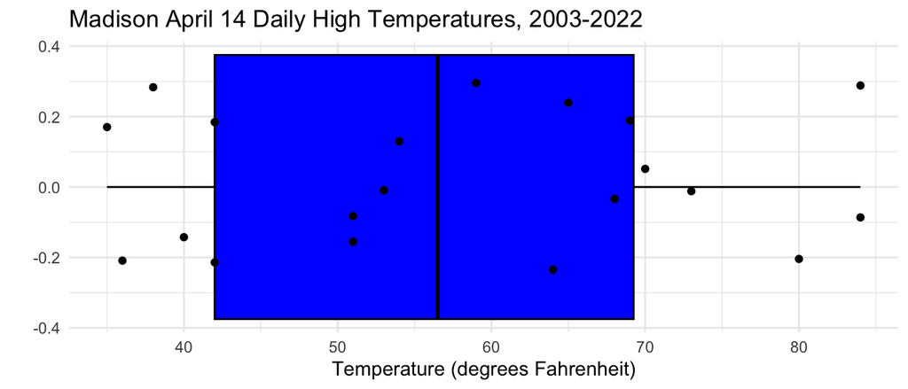

```r
ggplot(april_14, aes(x = tmax)) +
  geom_boxplot(color = "black", fill = "blue",
               coef = Inf) +
  geom_point(aes(y = 0),
             position = position_jitter(width = 0, height = 0.3)) +
  xlab("Temperature (degrees Fahrenheit)") +
  ggtitle("Madison April 14 Daily High Temperatures, 2003-2022") +
  ylab("")
```

> Over the 20 year period, daily high temperatures were fairly uniformly distributed between 35 and 85 degrees Fahrenheit. There is no strong skewness.

**2.** Compare the standard normal distribution with the t distribution with 19 degrees of freedom.

- Calculate the 0.975 quantiles from each of these two distribution.
- On the same graph, display the density functions of these two distributions, using blue for normal and red for t.
  - Add colored (use the same color scheme) dashed vertical lines at the corresponding 0.975 quantiles.
  - Shade the area in tail areas below the 0.025 and above the 0.975 quantiles of each distribution, setting `alpha = 0.5` for partial transparency.

#### Solution

```r
q_0.975 = tibble(z = qnorm(0.975),
       t = qt(0.975, 19))

q_0.975
```

```
## # A tibble: 1 × 2
##       z     t
##   <dbl> <dbl>
## 1  1.96  2.09
```

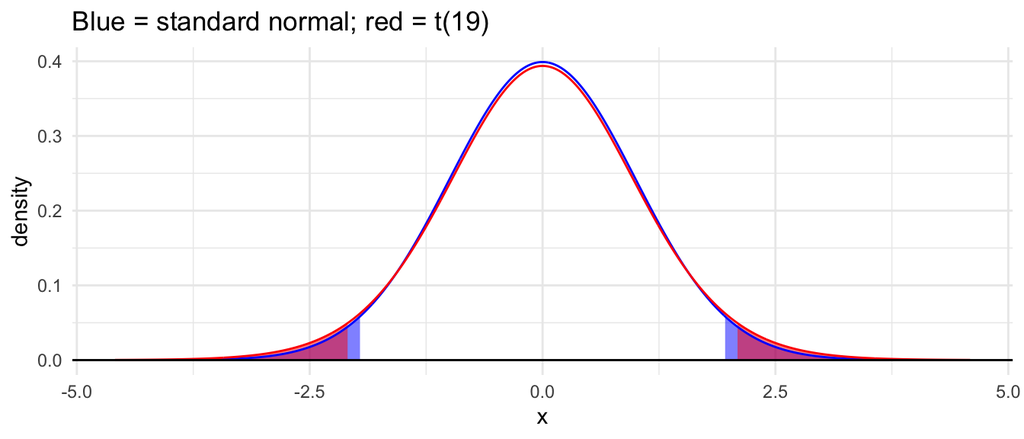

```r
ggplot() +
  geom_norm_fill(b = -q_0.975$z,
                 fill = "blue", alpha = 0.5) +
  geom_norm_fill(a = q_0.975$z,
                 fill = "blue", alpha = 0.5) +
  geom_t_fill(df = 19, b = -q_0.975$t,
                 fill = "red", alpha = 0.5) +
  geom_t_fill(df = 19, a = q_0.975$t,
                 fill = "red", alpha = 0.5) +
  geom_norm_density(color = "blue") +
  geom_t_density(df = 19, color = "red") +
  geom_hline(yintercept = 0) +
  ylab("density") +
  ggtitle("Blue = standard normal; red = t(19)")
```

**3.** Using the data from Problem 1:

- Construct a 95% confidence interval for $\mu$ using the theory of the t distribution by direct calculation using the summary statistics from the first part of the problem.
- Then use the `t.test()` function to verify your calculation.
- Interpret the interval in context.

#### Solution

- Direct calculation

```r
ci = april_14_sum$mean +
  c(-1,1) * qt(0.975, 19) * april_14_sum$sd / sqrt(20)

ci
```

```
## [1] 50.38426 65.41574
```

- Using `t.test()`

```r
t.test(april_14$tmax)
```

```
##
##  One Sample t-test
##
## data:  april_14$tmax
## t = 16.124, df = 19, p-value = 1.534e-12
## alternative hypothesis: true mean is not equal to 0
## 95 percent confidence interval:
##  50.38426 65.41574
## sample estimates:
## mean of x
##      57.9
```

> We are 95% confident that the expected mean high temperature on April 14 in Madison in recent decades is between 50.4 and 65.4 degrees Fahrenheit.

**4.** The historical average daily high temperature in Madison in April prior to 2000 is 55.6 degrees Farhenheit. Let $\mu$ be the expected daily high temperature on April 14 in the past two recent decades.

- Use a hypothesis test to test if $\mu$ equals 55.6 degrees versus the alternative that it is different. Include all steps as in the lecture notes.
- Conclude your hypothesis test with an interpretation in context which states your conclusion in plain language without technical jargon and summarizes the statistical evidence to support your conclusion in a statement surrounded by parentheses.

#### Solution

- **Parameter**: $\mu$ is the expected daily high temperature on April 14 in the past two recent decades.
- **Model**: $X_1, \ldots, X_n \sim F(\mu, \sigma)$
- **Hypotheses**:

$H_0: \mu = 55.6$  
$H_a: \mu \neq 55.6$

- **Test Statistic**:

$t = (\bar{x} - 55.6) / (s / \sqrt{n})$

```r
t_stat = (april_14_sum$mean - 55.6) / (april_14_sum$sd / sqrt(april_14_sum$n))

t_stat
```

```
## [1] 0.6405167
```

- **Null Distribution**: Under $H_0$, the test statistic has a t distribution with 19 degrees of freedom.
- **P-value**:

```r
p_value = 2*pt(-t_stat, 19)
p_value
```

```
## [1] 0.5294866
```

- **Interpretation**:

> There is very little evidence that the expected mean daily temperature on April 14 in the past 20 years is differs from the historical mean of 55.6 degrees Fahrenheit ($p = 0.53$, two-sided t test, 19 df).
- We can compare the p-value calculation using `t.test()`.

```r
t.test(april_14$tmax, mu = 55.6)
```

```
##
##  One Sample t-test
##
## data:  april_14$tmax
## t = 0.64052, df = 19, p-value = 0.5295
## alternative hypothesis: true mean is not equal to 55.6
## 95 percent confidence interval:
##  50.38426 65.41574
## sample estimates:
## mean of x
##      57.9
```

**5.** This problem asks you to compare the latest date in each winter when there was at least one inch of snow for two different time periods using the official Madison weather data and the years 1903–1922:

- Create a data set with the latest date from January to June in each year where there was at least one inch of snow for the years 1903–1922 and 2003–2022.
- Use the **lubridate** function `yday()` to create a new variable `yday` by converting this date into the number of days after December 31.
- Add a variable named `period` which has the value `"early 1900s"` for years 1903–1922 and `"early 2000s"` for the years 2003–2022.
- Calculate the sample size, the sample mean, and the sample standard deviation for each period.
- Create a graph to compare these two distributions.

#### Solution

```r
## latest snow more than one inch
prob5 = official %>%
  mutate(year = year(date)) %>%
  filter(month(date) <= 6) %>%
  select(date, year, snow) %>%
  drop_na() %>%
  filter(snow >= 1) %>%
  group_by(year) %>%
  summarize(latest = max(date)) %>%
  mutate(yday = yday(latest)) %>%
  filter(between(year, 1903, 1922) | between(year, 2003, 2022)) %>%
  mutate(period = case_when(
    year < 2000 ~ "early 1900s",
    year > 2000 ~ "early 2000s"))

prob5_sum = prob5 %>%
  group_by(period) %>%
  summarize(n = n(), mean = mean(yday), sd = sd(yday), se = sd/sqrt(n))

prob5_sum
```

```
## # A tibble: 2 × 5
##   period          n  mean    sd    se
##   <chr>       <int> <dbl> <dbl> <dbl>
## 1 early 1900s    20  84.0  19.8  4.42
## 2 early 2000s    20  90.9  16.8  3.76
```

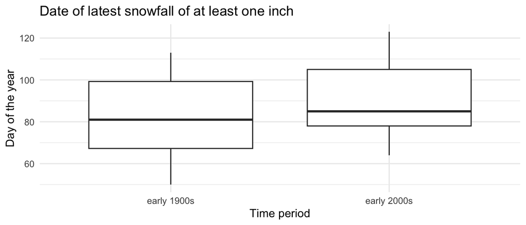

```r
g = ggplot(prob5, aes(x = period, y = yday)) +
  geom_boxplot(coef = Inf) +
  xlab("Time period") +
  ylab("Day of the year") +
  ggtitle("Date of latest snowfall of at least one inch")

g
```

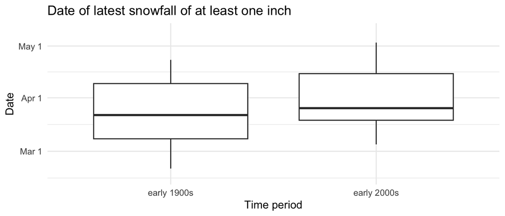

```r
## graph with an improved y axis
g +
  scale_y_continuous(
    breaks = yday(c("2023-02-01",
                    "2023-03-01",
                    "2023-04-01",
                    "2023-05-01")),
    labels = c("Feb 1", "Mar 1", "Apr 1", "May 1"),
    limits = c(45, 130)) +
  ylab("Date")
```

**6.** Using the data from the previous problem:

- Use `t.test()` to construct a confidence interval for the difference in the mean last day of at least one inch of snow between these two time periods.
  - Interpret the confidence interval in context
- Use `t.test()` to test the hypothesis that the population mean last days of at least one inch of snow are identical in the two time periods versus the alternative that they are different.

#### Solution

```r
x = prob5 %>%
  filter(period == "early 1900s") %>%
  pull(yday)

y = prob5 %>%
  filter(period == "early 2000s") %>%
  pull(yday)

t.test(x,y)
```

```
##
##  Welch Two Sample t-test
##
## data:  x and y
## t = -1.1802, df = 37.047, p-value = 0.2454
## alternative hypothesis: true difference in means is not equal to 0
## 95 percent confidence interval:
##  -18.609478   4.909478
## sample estimates:
## mean of x mean of y
##     84.05     90.90
```

> We are 95% confident that the difference in the expected date of the last day with at least one inch of snow (early 1900s minus early 2000s) is between $-18.6$ and 4.9 days.

> There is little evidence that the expected last date with at least one inch of snow differs between the early 1900s and the early 2000s ($p = 0.25$, $t = -1.18$, two-sided Welch t-test, df = 37.05).

**7.** Using the Boston Marathon data, treat the finishing times of men aged 35–39 in 2010 as a sample from a larger population of men worldwide who could have completed the Boston marathon that year.

- Calculate a numerical summary of the times to finish the race from this sample, including the sample size, sample mean, sample standard deviation, and the 0.10, 0.25, 0.50, 0.75, and 0.90 quantiles.
- Choose a type of graph and display the distribution of the sample finish times.
- Find a 95% confidence interval for the mean finishing time in the population using methods of the t distribution by direct calculation
- Repeat the calculations using the `t.test()` function
- Interpret this confidence interval in context following the format of examples from lecture.

#### Solution

```r
bm = read_csv("../../data/boston-marathon-data.csv")

prob7 = bm %>%
  filter(Year == 2010 &
           Sex == "male" &
           Age_Range == "35-39")
```

#### summary statistics

```r
prob7_sum = prob7 %>%
  summarize(n = n(),
            mean = mean(Time),
            sd = sd(Time),
            se = sd/sqrt(n),
            q10 = quantile(Time, 0.10),
            q25 = quantile(Time, 0.25),
            median = median(Time),
            q75 = quantile(Time, 0.75),
            q90 = quantile(Time, 0.90))

prob7_sum %>%
  print(width = Inf)
```

```
## # A tibble: 1 × 9
##       n  mean    sd    se   q10   q25 median   q75   q90
##   <int> <dbl> <dbl> <dbl> <dbl> <dbl>  <dbl> <dbl> <dbl>
## 1  1769  214.  38.5 0.915  177.  189.   202.  230.  272.
```

#### graph

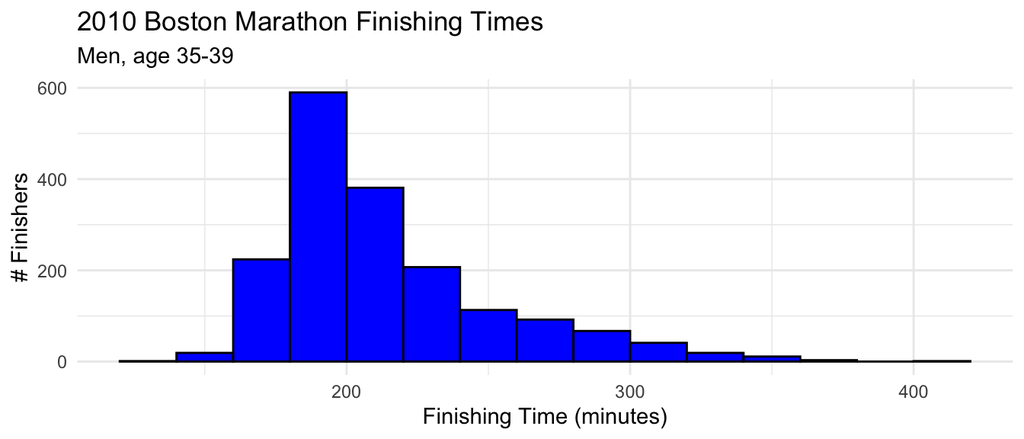

```r
ggplot(prob7, aes(x = Time)) +
  geom_histogram(boundary = 200, binwidth = 20,
                 color = "black", fill = "blue") +
  xlab("Finishing Time (minutes)") +
  ylab("# Finishers") +
  ggtitle("2010 Boston Marathon Finishing Times",
          subtitle = "Men, age 35-39")
```

#### direct calculation

```r
ci = prob7_sum$mean +
  c(-1,1) * qt(0.975, prob7_sum$n - 1) *
  prob7_sum$sd / sqrt(prob7_sum$n)

ci
```

```
## [1] 212.2629 215.8531
```

#### `t.test()`

```r
t.test(prob7$Time)
```

```
##
##  One Sample t-test
##
## data:  prob7$Time
## t = 233.88, df = 1768, p-value < 2.2e-16
## alternative hypothesis: true mean is not equal to 0
## 95 percent confidence interval:
##  212.2629 215.8531
## sample estimates:
## mean of x
##   214.058
```

#### interpretation

> We are 95% confident that the expected mean finish time for the population of men aged 35-39 to finish the Boston marathon in 2010 is between 212.26 and 215.85 minutes.

**8.** Treat the finishing times in the Boston Marathon of men aged 35–39 in 2010 and 2011 as two different independent samples. Is there evidence that the mean time to finish the race among a population of potential finishers changed during these two years? Conduct a hypothesis test to support your conclusion.

```r
x = prob7 %>%
  pull(Time)

y = bm %>%
  filter(Year == 2011 &
           Sex == "male" &
           Age_Range == "35-39") %>%
  pull(Time)

t.test(x,y)
```

```
##
##  Welch Two Sample t-test
##
## data:  x and y
## t = 1.2249, df = 3608.6, p-value = 0.2207
## alternative hypothesis: true difference in means is not equal to 0
## 95 percent confidence interval:
##  -0.9477035  4.1031083
## sample estimates:
## mean of x mean of y
##  214.0580  212.4803
```

- Let $\mu_1$ and $\mu_2$ be the population mean times for men aged 35–39 to finish the Boston marathon in 2010 and 2011 respectively.
- Test $H_0: \mu_1 = \mu_2$ versus $H_a: \mu_1 \neq \mu_2$.
- The test statistic is $t = 1.225$ and the p-value is 0.22.

> The observed data is consistent with there being no difference in the population mean finish times for men aged 35-39 to complete the Boston marathon between 2010 and 2011 ($p = 0.22$, two-sided Welch t test, $t = 1.22$, df = 3609).
- Note that a 95% confidence interval for the difference in population means ranges from $-0.95$ to 4.10 minutes and zero is one of the plausible values for the true difference at a 95% level of confidence, consistent with the p-value being larger than 0.05.